# Evaluation ratings and giving

# Goals

Look at the relationship between evaluation and qualification ratings and subsequent (5-year?) giving.

# Setup

```r
library(tidyverse)
library(lubridate)
library(readxl)
library(scales)
library(foreach)
library(wranglR)

# Hide the dplyr .groups message
options(dplyr.summarise.inform = FALSE)
```

# Eval data

```r
evals <- read_xlsx("data/2024-04-12 all evals.xlsx", guess_max = 1E6)
```

```r
# Fix datatypes
evals <- evals %>%
  # Factors
  mutate(
    across(
      c(PRIMARY_IND, RECORD_STATUS_CODE, PROGRAM_GROUP, EVALUATION_TYPE, EVALUATION_TYPE_DESC
           , ACTIVE_IND, RATING_CODE, RATING_DESC, EVALUATOR_ID_NUMBER)
      , factor
    )
  ) %>%
  # Numerics
  mutate(
    FIRST_KSM_YEAR = as.numeric(FIRST_KSM_YEAR)
    , eval_fy = wranglR::ToFiscalDate(EVALUATION_DATE, start.month = 9)
  )
```

```r
summary(evals)
```

```
 EVALUATION_ID     ID_NUMBER          PROSPECT_ID     PRIMARY_IND  REPORT_NAME
 Min.   :100002   Length:32399       Min.   : 90004   N   : 1245   Length:32399
 1st Qu.:210205   Class :character   1st Qu.:107164   Y   : 9798   Class :character
 Median :252477   Mode  :character   Median :120140   NA's:21356   Mode  :character
 Mean   :245593                      Mean   :119307
 3rd Qu.:288009                      3rd Qu.:130767
 Max.   :308839                      Max.   :163588
                                     NA's   :21356
 RECORD_STATUS_CODE DEGREES_CONCAT     FIRST_KSM_YEAR PROGRAM_GROUP  EVALUATION_TYPE
 A:30753            Length:32399       Min.   :1800   EMP   : 4002   PR:21365
 C:   87            Class :character   1st Qu.:1983   EXECED:  306   UR:11034
 D: 1419            Mode  :character   Median :1992   FT    :21806
 L:  140                               Mean   :1991   NONGRD:   10
                                       3rd Qu.:2001   PHD   :  177
                                       Max.   :2024   TMP   : 6094
                                       NA's   :14     UNK   :    4
                EVALUATION_TYPE_DESC EVALUATION_DATE                  ACTIVE_IND
 Prospect Research        :21365     Min.   :1995-11-15 00:00:00.00   N   :11177
 University Overall Rating:11034     1st Qu.:2010-12-08 00:00:00.00   Y   :21188
                                     Median :2016-12-02 00:00:00.00   NA's:   34
                                     Mean   :2016-01-18 00:50:35.17
                                     3rd Qu.:2021-11-08 00:00:00.00
                                     Max.   :2024-04-11 00:00:00.00
                                     NA's   :2
  RATING_CODE             RATING_DESC   RATING_AMT_LOW        XCOMMENT
 4      :7909   D  $100K - $249K:7909   Min.   :    10000   Length:32399
 5      :5780   C  $250K - $499K:5780   1st Qu.:    50000   Class :character
 3      :4318   E  $50K - $99K  :4318   Median :   100000   Mode  :character
 1      :3372   G  $10K - $24K  :3372   Mean   :   772902
 2      :3206   F  $25K - $49K  :3206   3rd Qu.:   250000
 6      :2813   B  $500K - $999K:2813   Max.   :100000000
 (Other):5001   (Other)         :5001   NA's   :113
 EVALUATOR_ID_NUMBER EVALUATOR_RPT_NAME    eval_fy
 0000772232: 8447    Length:32399       Min.   :1996
 0000431868: 2151    Class :character   1st Qu.:2011
 0000643958: 1160    Mode  :character   Median :2017
 0000258109: 1112                       Mean   :2016
 0000417255: 1051                       3rd Qu.:2022
 (Other)   :16978                       Max.   :2024
 NA's      : 1500                       NA's   :2
```

## Eval exploration

How many rated by grad year?

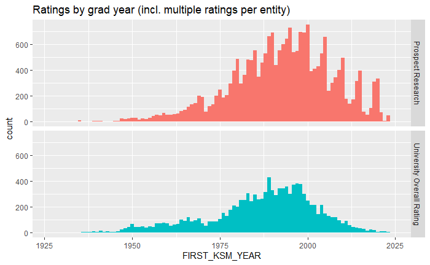

```r
evals %>%
  filter(FIRST_KSM_YEAR >= 1900) %>%
  ggplot(aes(x = FIRST_KSM_YEAR, fill = EVALUATION_TYPE_DESC)) +
  geom_histogram(binwidth = 1) +
  labs(title = "Ratings by grad year (incl. multiple ratings per entity)") +
  guides(fill = "none") +
  facet_grid(EVALUATION_TYPE_DESC ~ .)
```

How many rated by program?

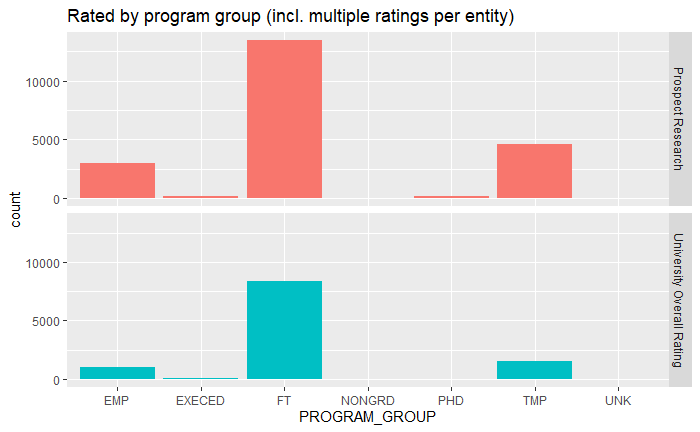

```r
evals %>%
  ggplot(aes(x = PROGRAM_GROUP, fill = EVALUATION_TYPE_DESC)) +
  geom_bar() +
  labs(title = "Rated by program group (incl. multiple ratings per entity)") +
  guides(fill = "none") +
  facet_grid(EVALUATION_TYPE_DESC ~ .)
```

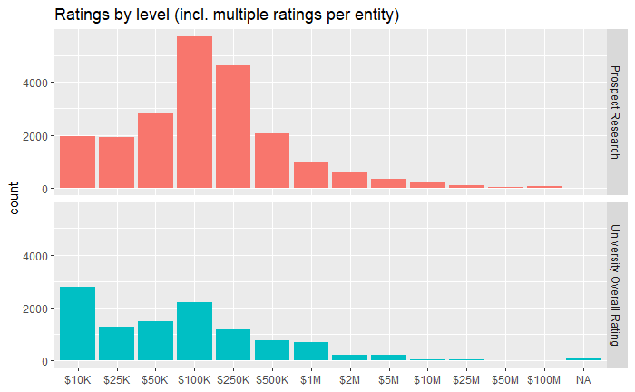

```r
rating_amt_low_labs <- evals %>%
  select(RATING_AMT_LOW) %>%
  unique() %>%
  arrange(RATING_AMT_LOW) %>%
  mutate(
    rating = case_when(
      # Skip NULL
      is.na(RATING_AMT_LOW) ~ "NA"
      # Over 1M gets M
      , RATING_AMT_LOW >= 1E6 ~ "$" %>% paste0(round(RATING_AMT_LOW / 1E6, 1), "M")
      # Else use K
      , TRUE ~ "$" %>% paste0(round(RATING_AMT_LOW / 1E3, 1), "K")
    )
  )

rating_amt_labs <- rating_amt_low_labs$rating
names(rating_amt_labs) <- rating_amt_low_labs$RATING_AMT_LOW

evals %>%
  ggplot(aes(x = factor(RATING_AMT_LOW), fill = EVALUATION_TYPE_DESC)) +
  geom_bar() +
  labs(title = "Ratings by level (incl. multiple ratings per entity)", x = NULL) +
  guides(fill = "none") +
  scale_x_discrete(labels = rating_amt_labs) +
  facet_grid(EVALUATION_TYPE_DESC ~ .)
```

Correlation between grad year and ratings?

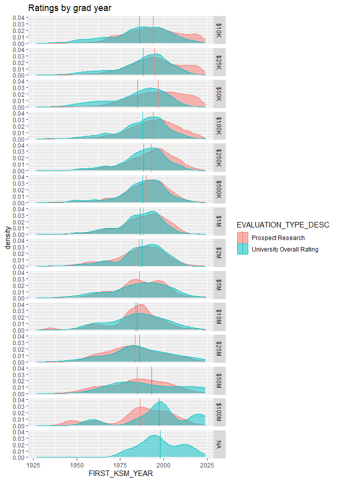

```r
evals %>%
  mutate(rating = factor(RATING_AMT_LOW)) %>%
  filter(FIRST_KSM_YEAR >= 1900) %>%
  ggplot(aes(x = FIRST_KSM_YEAR
             , color = EVALUATION_TYPE_DESC, fill = EVALUATION_TYPE_DESC)) +
  geom_density(alpha = .5) +
  labs(title = "Ratings by grad year") +
  facet_grid(rating ~ .
             , labeller = labeller(rating = rating_amt_labs)) +
  # Group means
  geom_vline(data = evals %>%
               mutate(rating = factor(RATING_AMT_LOW)) %>%
               group_by(rating, EVALUATION_TYPE_DESC) %>%
               mutate(yrmean = mean(FIRST_KSM_YEAR, na.rm = TRUE))
             , aes(xintercept = yrmean, color = EVALUATION_TYPE_DESC))
```

Relationship between program group and ratings?

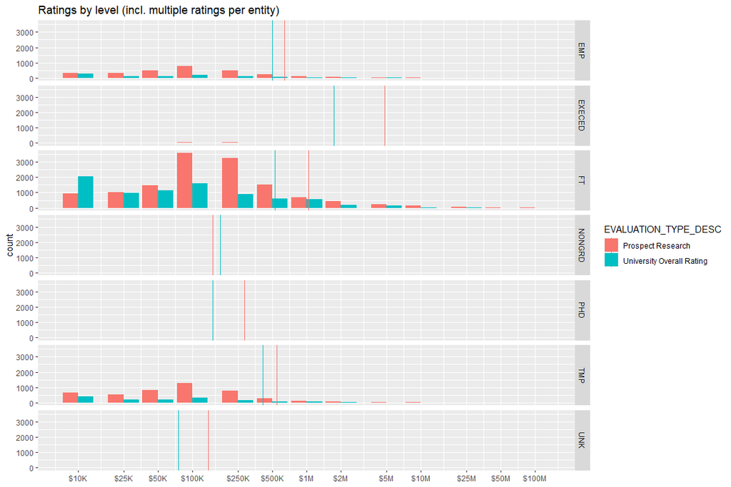

```r
evals %>%
  ggplot(aes(x = RATING_AMT_LOW, fill = EVALUATION_TYPE_DESC)) +
  geom_bar(position = "dodge") +
  labs(title = "Ratings by level (incl. multiple ratings per entity)", x = NULL) +
  scale_x_log10(breaks = names(rating_amt_labs) %>% as.numeric
                , labels = rating_amt_labs) +
  facet_grid(PROGRAM_GROUP ~ .) +
  # theme(axis.text.x = element_text(angle = 90, vjust = 0.5, hjust = 1)) +
  # Group means
  geom_vline(data = evals %>%
             group_by(PROGRAM_GROUP, EVALUATION_TYPE_DESC) %>%
             mutate(rtmean = mean(RATING_AMT_LOW, na.rm = TRUE))
           , aes(xintercept = rtmean, color = EVALUATION_TYPE_DESC))
```

Can’t tell anything; redo with density rather than counts. Also filter for only the big programs.

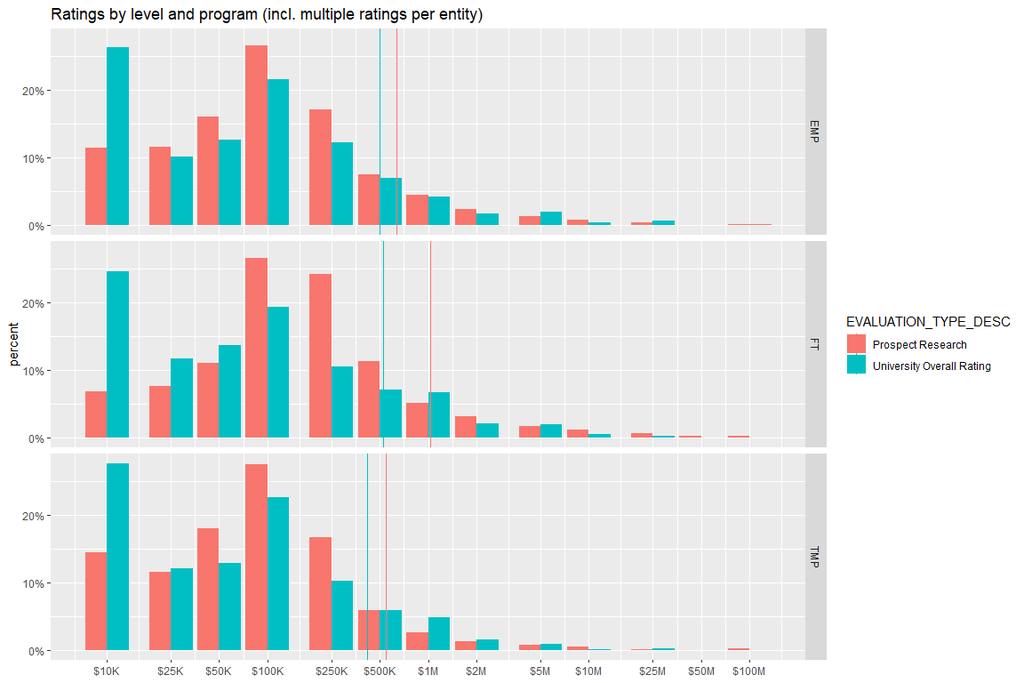

```r
evals %>%
  filter(PROGRAM_GROUP %in% c("FT", "EMP", "TMP")) %>%
  group_by(PROGRAM_GROUP, EVALUATION_TYPE_DESC) %>%
  mutate(
    n = n()
    , pct = n/sum(n)
  ) %>%
  group_by(PROGRAM_GROUP, EVALUATION_TYPE_DESC, RATING_AMT_LOW) %>%
  summarise(
    percent = sum(pct)
  ) %>%
  ggplot(aes(x = RATING_AMT_LOW, y = percent, fill = EVALUATION_TYPE_DESC)) +
  geom_bar(stat = "identity", position = "dodge") +
  labs(title = "Ratings by level and program (incl. multiple ratings per entity)", x = NULL) +
  scale_x_log10(breaks = names(rating_amt_labs) %>% as.numeric
                , labels = rating_amt_labs) +
  scale_y_continuous(labels = scales::percent) +
  facet_grid(PROGRAM_GROUP ~ .) +
  # theme(axis.text.x = element_text(angle = 90, vjust = 0.5, hjust = 1)) +
  # Group means
  geom_vline(data = evals %>%
             filter(PROGRAM_GROUP %in% c("FT", "EMP", "TMP")) %>%
             group_by(PROGRAM_GROUP, EVALUATION_TYPE_DESC) %>%
             mutate(rtmean = mean(RATING_AMT_LOW, na.rm = TRUE))
           , aes(xintercept = rtmean, color = EVALUATION_TYPE_DESC))
```

FT ratings apparently skew a bit higher and TMP a bit lower, but no big differences.

# Gift data

```r
gifts <- read_xlsx("data/2024-04-25 KSM gifts from rated.xlsx", guess_max = 1E6)
```

```r
# Fix datatypes
gifts <- gifts %>%
  # Factors
  mutate(
    across(
      c(TX_GYPM_IND, TRANSACTION_TYPE, ASSOCIATED_DESC, PAYMENT_TYPE, ALLOC_SHORT_NAME)
      , factor
    )
  )
```

## Gift exploration

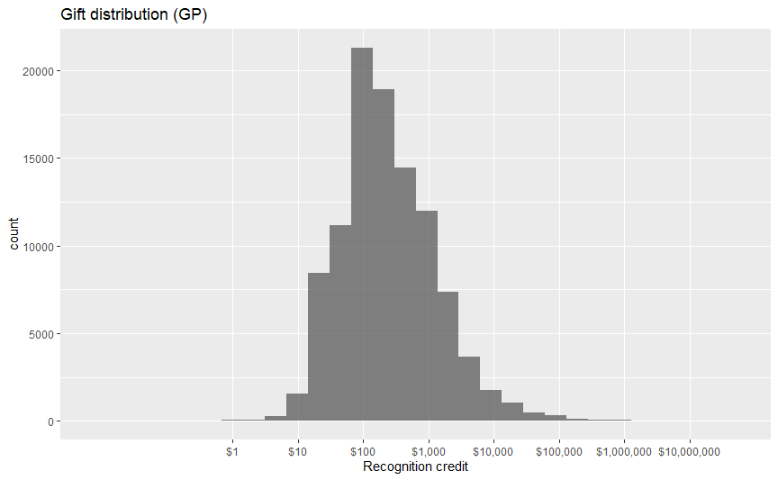

```r
gifts %>%
  ggplot(aes(x = RECOGNITION_CREDIT)) +
  geom_histogram(alpha = .75, binwidth = .33) +
  scale_x_log10(breaks = c(10^(0:7)), labels = scales::dollar, minor_breaks = NULL) +
  labs(title = "Gift distribution (GP)", x = "Recognition credit")
```

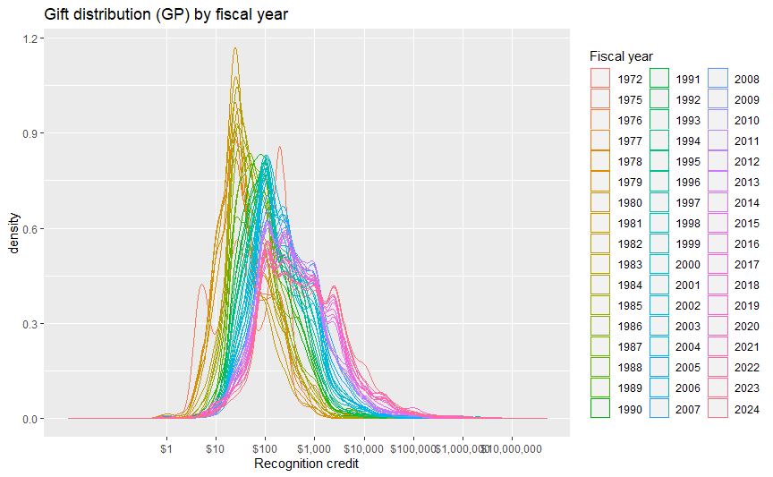

```r
gifts %>%
  ggplot(aes(x = RECOGNITION_CREDIT)) +
  geom_density(aes(color = factor(FISCAL_YEAR)), alpha = .5, bw = .15) +
  scale_x_log10(breaks = c(10^(0:7)), labels = scales::dollar, minor_breaks = NULL) +
  labs(title = "Gift distribution (GP) by fiscal year", x = "Recognition credit", color = "Fiscal year")
```

Based on the color gradient, looks like the average has been shifting right over time.

Look at average gift by year.

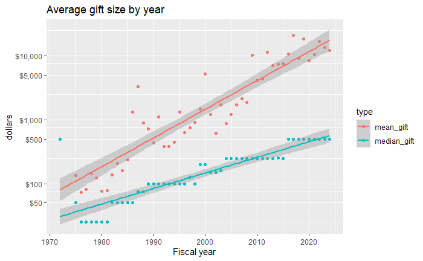

```r
meangifts <- gifts %>%
  group_by(FISCAL_YEAR) %>%
  summarise(
    mean_gift = mean(RECOGNITION_CREDIT)
    , median_gift = median(RECOGNITION_CREDIT)
  ) %>%
  pivot_longer(mean_gift:median_gift, names_to = 'type', values_to = 'dollars')

meangifts %>%
  ggplot(aes(x = FISCAL_YEAR, y = dollars, color = type)) +
  geom_point() +
  scale_y_log10(labels = dollar_format(1)
                , breaks = c(10*10^(0:4), 50*10^(0:4))
                , minor_breaks = c(25*10^(0:4), 75*10^(0:4))) +
  geom_smooth(method = 'lm') +
  labs(x = "Fiscal year", title = "Average gift size by year")
```

Pretty clear log linear trend. Interesting that median is a stepwise function; what happened in the change years?

```r
lm_mean <- meangifts %>%
  filter(type == "mean_gift") %>%
  lm(
    log10(dollars) ~ FISCAL_YEAR
    , data = .
  )

lm_med <- meangifts %>%
  filter(type == "median_gift") %>%
  lm(
    log10(dollars) ~ FISCAL_YEAR
    , data = .
  )
```

```r
summary(lm_mean)
```

```
Call:
lm(formula = log10(dollars) ~ FISCAL_YEAR, data = .)

Residuals:
     Min       1Q   Median       3Q      Max
-0.47073 -0.21128 -0.07987  0.12004  0.93897

Coefficients:
              Estimate Std. Error t value Pr(>|t|)
(Intercept) -86.923301   5.742022  -15.14   <2e-16 ***
FISCAL_YEAR   0.045046   0.002872   15.68   <2e-16 ***
---
Signif. codes:  0 ‘***’ 0.001 ‘**’ 0.01 ‘*’ 0.05 ‘.’ 0.1 ‘ ’ 1

Residual standard error: 0.3034 on 49 degrees of freedom
Multiple R-squared:  0.8339,    Adjusted R-squared:  0.8305
F-statistic: 245.9 on 1 and 49 DF,  p-value: < 2.2e-16
```

```r
summary(lm_med)
```

```
Call:
lm(formula = log10(dollars) ~ FISCAL_YEAR, data = .)

Residuals:
     Min       1Q   Median       3Q      Max
-0.30792 -0.07603 -0.01570  0.06159  1.21277

Coefficients:
              Estimate Std. Error t value Pr(>|t|)
(Intercept) -46.643219   3.943700  -11.83 5.75e-16 ***
FISCAL_YEAR   0.024406   0.001973   12.37  < 2e-16 ***
---
Signif. codes:  0 ‘***’ 0.001 ‘**’ 0.01 ‘*’ 0.05 ‘.’ 0.1 ‘ ’ 1

Residual standard error: 0.2084 on 49 degrees of freedom
Multiple R-squared:  0.7575,    Adjusted R-squared:  0.7525
F-statistic:   153 on 1 and 49 DF,  p-value: < 2.2e-16
```

Of course, $r^2$ is inflated by averaging the data but it’s interesting. Look closer at means.

```r
lm_gifts <- gifts %>%
  filter(TX_GYPM_IND == 'G' & LEGAL_AMOUNT > 0) %>%
  lm(
    log10(LEGAL_AMOUNT) ~ FISCAL_YEAR
    , data = .
  )

summary(lm_gifts)
```

```
Call:
lm(formula = log10(LEGAL_AMOUNT) ~ FISCAL_YEAR, data = .)

Residuals:
    Min      1Q  Median      3Q     Max
-4.4031 -0.4245 -0.0755  0.3883  3.7592

Coefficients:
              Estimate Std. Error t value Pr(>|t|)
(Intercept) -40.547282   0.373097  -108.7   <2e-16 ***
FISCAL_YEAR   0.021358   0.000186   114.8   <2e-16 ***
---
Signif. codes:  0 ‘***’ 0.001 ‘**’ 0.01 ‘*’ 0.05 ‘.’ 0.1 ‘ ’ 1

Residual standard error: 0.6131 on 76040 degrees of freedom
Multiple R-squared:  0.1477,    Adjusted R-squared:  0.1477
F-statistic: 1.318e+04 on 1 and 76040 DF,  p-value: < 2.2e-16
```

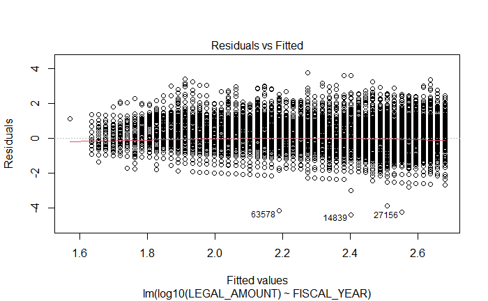

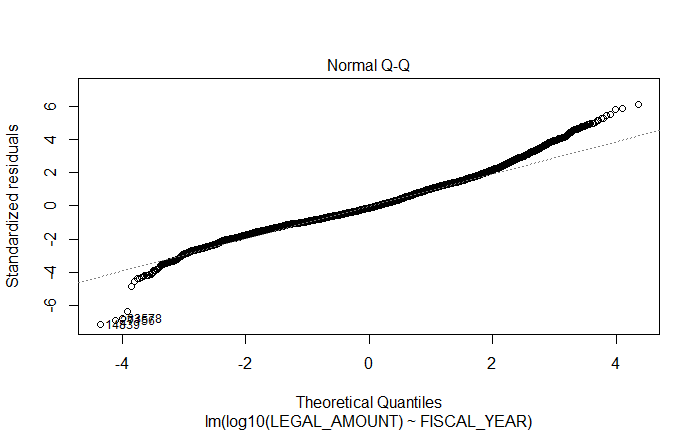

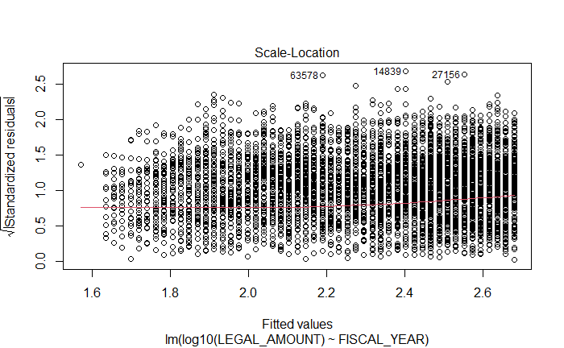

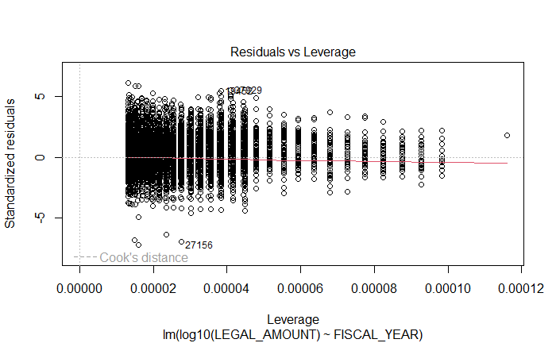

```r
plot(lm_gifts)
```

Thick-tailed distribution which is expected for (log) giving.

# Time and inflation trends

```r
cpiu <- read_xlsx(path = "data/CPI-U.xlsx", guess_max = 1E6) %>%
  mutate(
    stat = "cpiu"
  )
```

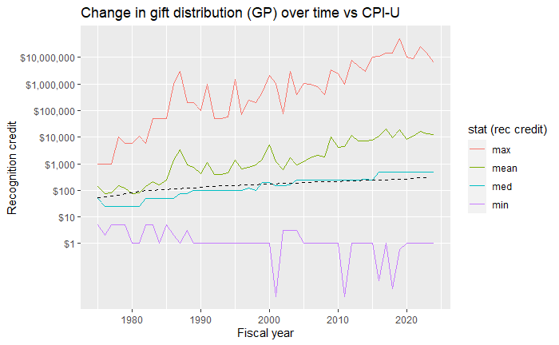

```r
gifts %>%
  group_by(FISCAL_YEAR) %>%
  summarise(
    min = min(RECOGNITION_CREDIT)
    , med = median(RECOGNITION_CREDIT)
    , mean = mean(RECOGNITION_CREDIT)
    , max = max(RECOGNITION_CREDIT)
  ) %>%
  pivot_longer(
    cols = min:max
    , names_to = "stat"
    , values_to = "recognition_credit"
  ) %>%
  filter(
    FISCAL_YEAR >= 1975
  ) %>%
  ggplot(aes(x = FISCAL_YEAR)) +
  geom_line(aes(y = recognition_credit, color = stat)) +
  geom_line(data = cpiu %>% filter(Year >= 1975), aes(x = Year, y = `CPI-U`), linetype = "dashed") +
  scale_y_log10(breaks = c(10^(0:7)), labels = scales::dollar, minor_breaks = NULL) +
  labs(y = "Recognition credit", x = "Fiscal year", color = "stat (rec credit)"
    , title = "Change in gift distribution (GP) over time vs CPI-U")
```

Average and median giving has outpaced inflation (dashed reference line).

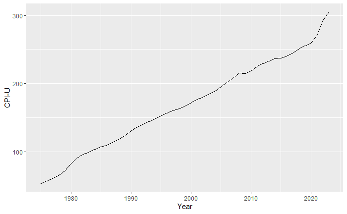

```r
cpiu %>%
  filter(Year >= 1975) %>%
  ggplot(aes(x = Year, y = `CPI-U`)) +
  geom_line()
```

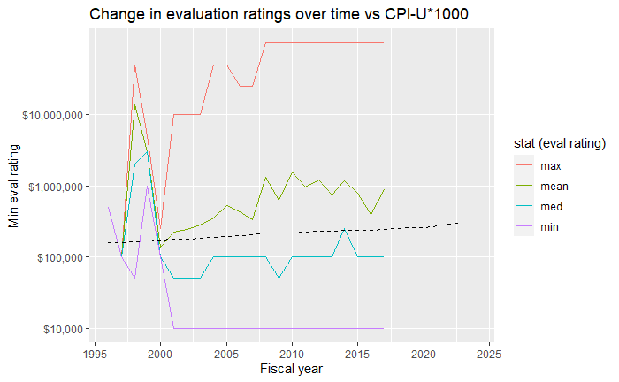

```r
summary_evals <- evals %>%
  group_by(eval_fy) %>%
  summarise(
    min = min(RATING_AMT_LOW)
    , med = median(RATING_AMT_LOW)
    , mean = mean(RATING_AMT_LOW)
    , max = max(RATING_AMT_LOW)
  ) %>%
  pivot_longer(
    cols = min:max
    , names_to = "stat"
    , values_to = "rating_amt_low"
  )

min_eval_fy = min(evals$eval_fy, na.rm = TRUE)

summary_evals %>%
  ggplot(aes(x = eval_fy)) +
  geom_line(aes(y = rating_amt_low, color = stat)) +
  geom_line(
    data = cpiu %>% filter(Year >= min_eval_fy) %>% mutate(`CPI-U` = `CPI-U`)
    , aes(x = Year, y = `CPI-U`*1000), linetype = "dashed") +
  scale_y_log10(breaks = c(10^(0:7)), labels = scales::dollar, minor_breaks = NULL) +
  labs(y = "Min eval rating", x = "Fiscal year", color = "stat (eval rating)"
    , title = "Change in evaluation ratings over time vs CPI-U*1000")
```

I suppose it’s dependent on the data window, but average eval rating appears to have outpaced inflation.

# Merged data

Look at total giving made within say 3 years of the evaluation rating.

```r
year_period <- 3

merged <- evals %>%
  # Join gifts table
  left_join(
    gifts %>% select(-REPORT_NAME)
    , by = c(ID_NUMBER = "ID_NUMBER")
  ) %>%
  # Identify any gifts outside of date range
  mutate(
    nogifts = is.na(DATE_OF_RECORD)
    , pre_rating_gift = DATE_OF_RECORD >= EVALUATION_DATE
    , counting_period_gift = (DATE_OF_RECORD - EVALUATION_DATE) <= days(365 * year_period)
    , include = nogifts | (pre_rating_gift & counting_period_gift)
  )
```

```r
merged$ID_NUMBER %>% unique() %>% length()
```

```
[1] 18139
```

```r
evals$ID_NUMBER %>% unique() %>% length()
```

```
[1] 18139
```

```r
merged_summary <- merged %>%
  group_by(ID_NUMBER, EVALUATION_ID, eval_fy, RATING_AMT_LOW, EVALUATION_TYPE) %>%
  summarise(
    gifts = ifelse(include, 1, 0) %>% sum()
    , gave = gifts > 0
    , post_eval_dollars = ifelse(include, ReplaceValues(RECOGNITION_CREDIT, NA, 0), 0) %>% sum()
  )
```

```r
merged_summary$ID_NUMBER %>% unique() %>% length()
```

```
[1] 18139
```

Good, didn’t filter out anyone.

## Exploration

```r
merged_summary %>% summary()
```

```
  ID_NUMBER         EVALUATION_ID       eval_fy     RATING_AMT_LOW      EVALUATION_TYPE
 Length:32399       Min.   :100002   Min.   :1996   Min.   :    10000   PR:21365
 Class :character   1st Qu.:210205   1st Qu.:2011   1st Qu.:    50000   UR:11034
 Mode  :character   Median :252477   Median :2017   Median :   100000
                    Mean   :245593   Mean   :2016   Mean   :   772902
                    3rd Qu.:288009   3rd Qu.:2022   3rd Qu.:   250000
                    Max.   :308839   Max.   :2024   Max.   :100000000
                                     NA's   :2      NA's   :113
     gifts            gave         post_eval_dollars
 Min.   : 0.0000   Mode :logical   Min.   :       0
 1st Qu.: 0.0000   FALSE:12754     1st Qu.:       0
 Median : 1.0000   TRUE :19643     Median :       0
 Mean   : 0.9995   NA's :2         Mean   :   23925
 3rd Qu.: 1.0000                   3rd Qu.:     500
 Max.   :43.0000                   Max.   :50000000
 NA's   :2                         NA's   :2
```

Remove NAs.

```r
merged_summary <- merged_summary %>% filter(!is.na(RATING_AMT_LOW))

merged_summary %>% summary()
```

```
  ID_NUMBER         EVALUATION_ID       eval_fy     RATING_AMT_LOW      EVALUATION_TYPE
 Length:32286       Min.   :100002   Min.   :1996   Min.   :    10000   PR:21365
 Class :character   1st Qu.:210143   1st Qu.:2011   1st Qu.:    50000   UR:10921
 Mode  :character   Median :252179   Median :2017   Median :   100000
                    Mean   :245484   Mean   :2016   Mean   :   772902
                    3rd Qu.:287990   3rd Qu.:2022   3rd Qu.:   250000
                    Max.   :308839   Max.   :2024   Max.   :100000000
                                     NA's   :2
     gifts            gave         post_eval_dollars
 Min.   : 0.0000   Mode :logical   Min.   :       0
 1st Qu.: 0.0000   FALSE:12720     1st Qu.:       0
 Median : 1.0000   TRUE :19564     Median :       0
 Mean   : 0.9991   NA's :2         Mean   :   23993
 3rd Qu.: 1.0000                   3rd Qu.:     500
 Max.   :43.0000                   Max.   :50000000
 NA's   :2                         NA's   :2
```

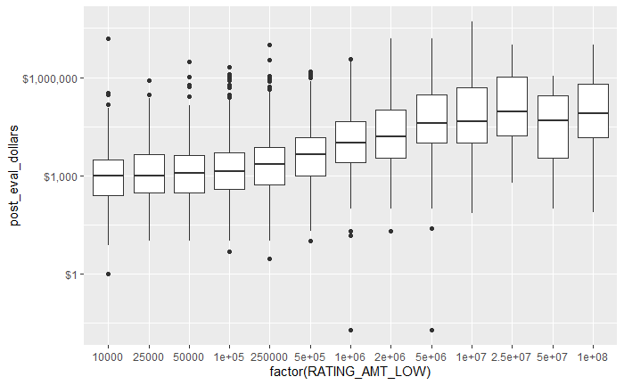

```r
merged_summary %>%
  ggplot(aes(x = factor(RATING_AMT_LOW), y = post_eval_dollars)) +
  geom_boxplot() +
  scale_y_log10(labels = dollar_format())
```

```r
lm1 <- merged_summary %>%
  lm(
    log10(post_eval_dollars + 1) ~ eval_fy + log10(RATING_AMT_LOW)
    , data = .
  )

summary(lm1)
```

```
Call:
lm(formula = log10(post_eval_dollars + 1) ~ eval_fy + log10(RATING_AMT_LOW),
    data = .)

Residuals:
    Min      1Q  Median      3Q     Max
-3.1145 -1.1796 -0.7869  1.4897  6.7746

Coefficients:
                       Estimate Std. Error t value Pr(>|t|)
(Intercept)           73.083941   2.889354   25.29   <2e-16 ***
eval_fy               -0.036960   0.001433  -25.80   <2e-16 ***
log10(RATING_AMT_LOW)  0.503594   0.012889   39.07   <2e-16 ***
---
Signif. codes:  0 ‘***’ 0.001 ‘**’ 0.01 ‘*’ 0.05 ‘.’ 0.1 ‘ ’ 1

Residual standard error: 1.625 on 32281 degrees of freedom
  (2 observations deleted due to missingness)
Multiple R-squared:  0.06421,   Adjusted R-squared:  0.06416
F-statistic:  1108 on 2 and 32281 DF,  p-value: < 2.2e-16
```

Frankly terrible $r^2$.

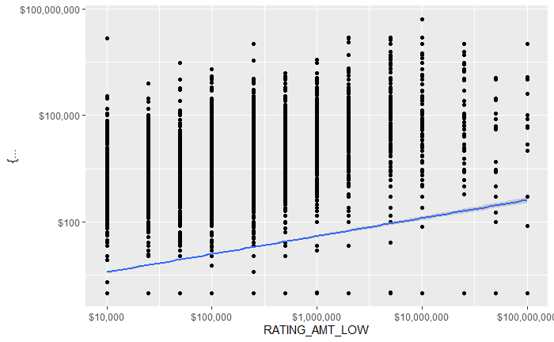

```r
merged_summary %>%
  ggplot(aes(x = RATING_AMT_LOW, y = {post_eval_dollars+1})) +
  geom_point() +
  geom_smooth(method = "lm") +
  scale_y_log10(labels = dollar_format()) +
  scale_x_log10(labels = dollar_format())
```

I’ve seen this before: the $0 amounts drag down the best fit line.

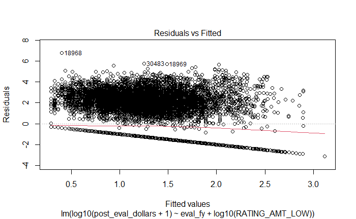

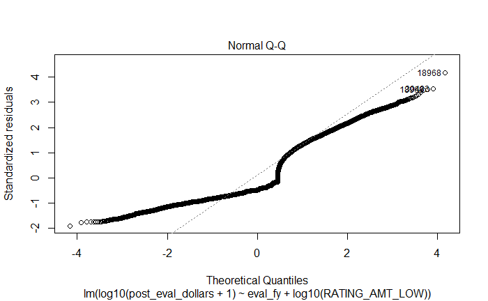

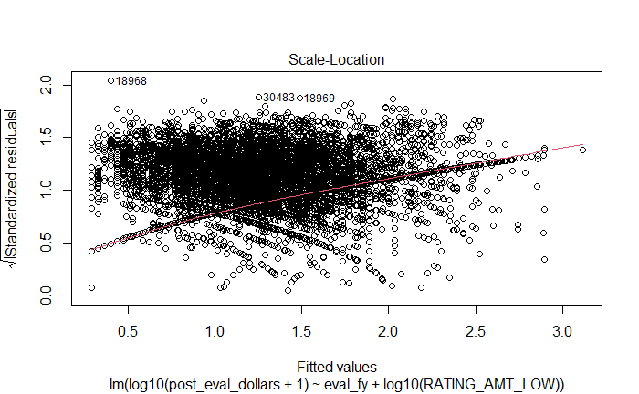

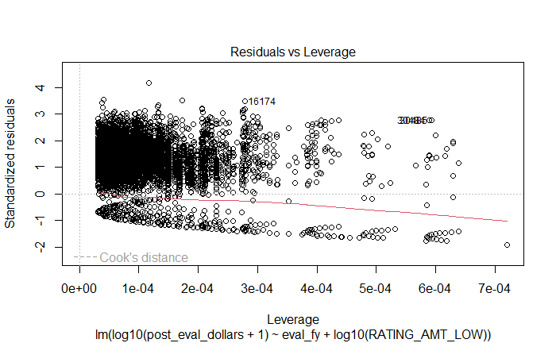

```r
plot(lm1)
```

Note the straight line on the residuals vs fitted plot, plus extreme skewness. Conditional on donors only (as per my original MG model)?

```r
lm2 <- merged_summary %>%
  filter(post_eval_dollars > 0) %>%
  lm(
    log10(post_eval_dollars) ~ eval_fy + log10(RATING_AMT_LOW)
    , data = .
  )

summary(lm2)
```

```
Call:
lm(formula = log10(post_eval_dollars) ~ eval_fy + log10(RATING_AMT_LOW),
    data = .)

Residuals:
    Min      1Q  Median      3Q     Max
-5.9511 -0.5925 -0.0122  0.5528  4.4384

Coefficients:
                       Estimate Std. Error t value Pr(>|t|)
(Intercept)           -8.027336   2.948314  -2.723  0.00649 **
eval_fy                0.004198   0.001465   2.865  0.00418 **
log10(RATING_AMT_LOW)  0.570371   0.012010  47.493  < 2e-16 ***
---
Signif. codes:  0 ‘***’ 0.001 ‘**’ 0.01 ‘*’ 0.05 ‘.’ 0.1 ‘ ’ 1

Residual standard error: 0.8706 on 10592 degrees of freedom
Multiple R-squared:  0.1781,    Adjusted R-squared:  0.1779
F-statistic:  1148 on 2 and 10592 DF,  p-value: < 2.2e-16
```

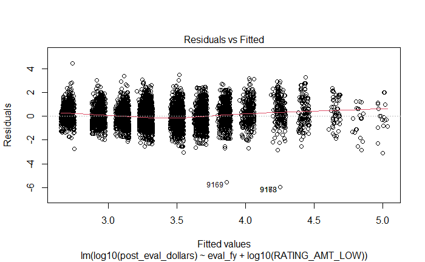

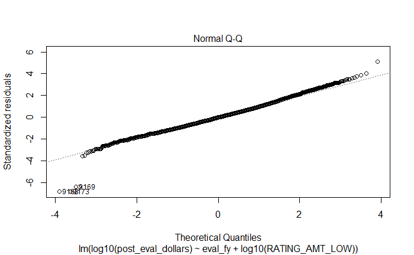

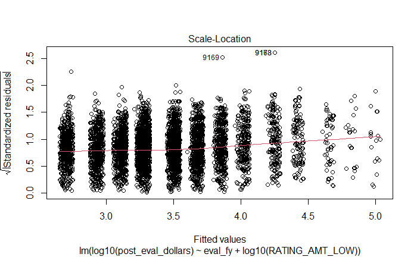

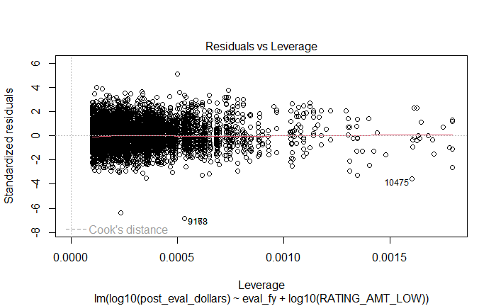

```r
plot(lm2)
```

Now we’re talking.

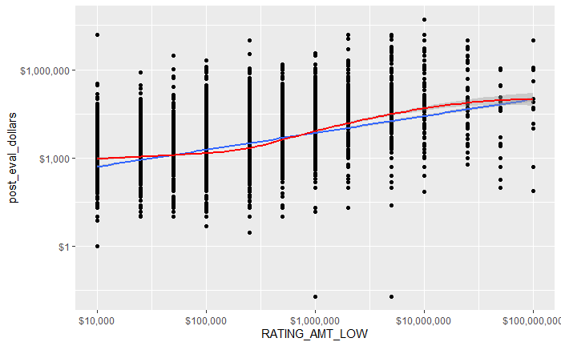

```r
merged_summary %>%
  filter(post_eval_dollars > 0) %>%
  ggplot(aes(x = RATING_AMT_LOW, y = post_eval_dollars)) +
  geom_point() +
  geom_smooth(method = "lm") +
  geom_smooth(method = "loess", color = "red") +
  scale_y_log10(labels = dollar_format()) +
  scale_x_log10(labels = dollar_format())
```

Much better. Red is a loess fit.

Do rating types make a difference?

```r
lm3 <- merged_summary %>%
  filter(post_eval_dollars > 0) %>%
  lm(
    log10(post_eval_dollars) ~ eval_fy + log10(RATING_AMT_LOW) * EVALUATION_TYPE
    , data = .
  )

summary(lm3)
```

```
Call:
lm(formula = log10(post_eval_dollars) ~ eval_fy + log10(RATING_AMT_LOW) *
    EVALUATION_TYPE, data = .)

Residuals:
    Min      1Q  Median      3Q     Max
-6.2446 -0.5650 -0.0241  0.5145  4.0938

Coefficients:
                                         Estimate Std. Error t value Pr(>|t|)
(Intercept)                             -5.625711   2.799077  -2.010   0.0445 *
eval_fy                                  0.002530   0.001391   1.819   0.0690 .
log10(RATING_AMT_LOW)                    0.711611   0.015450  46.059  < 2e-16 ***
EVALUATION_TYPEUR                        1.404156   0.120421  11.660  < 2e-16 ***
log10(RATING_AMT_LOW):EVALUATION_TYPEUR -0.163882   0.023241  -7.051 1.88e-12 ***
---
Signif. codes:  0 ‘***’ 0.001 ‘**’ 0.01 ‘*’ 0.05 ‘.’ 0.1 ‘ ’ 1

Residual standard error: 0.8257 on 10590 degrees of freedom
Multiple R-squared:  0.2609,    Adjusted R-squared:  0.2606
F-statistic: 934.4 on 4 and 10590 DF,  p-value: < 2.2e-16
```

Donors receiving a UOR are expected to give more than those just receiving a PR evaluation; presumably because the UOR indicates MG activity. How about just PR and giving?

```r
lm4 <- merged_summary %>%
  filter(post_eval_dollars > 0 & EVALUATION_TYPE == "PR") %>%
  lm(
    log10(post_eval_dollars) ~ eval_fy + log10(RATING_AMT_LOW)
    , data = .
  )

summary(lm4)
```

```
Call:
lm(formula = log10(post_eval_dollars) ~ eval_fy + log10(RATING_AMT_LOW),
    data = .)

Residuals:
    Min      1Q  Median      3Q     Max
-5.4249 -0.5611 -0.0436  0.5079  3.6805

Coefficients:
                       Estimate Std. Error t value Pr(>|t|)
(Intercept)           13.300762   3.154602   4.216 2.52e-05 ***
eval_fy               -0.006879   0.001568  -4.388 1.16e-05 ***
log10(RATING_AMT_LOW)  0.716776   0.015367  46.644  < 2e-16 ***
---
Signif. codes:  0 ‘***’ 0.001 ‘**’ 0.01 ‘*’ 0.05 ‘.’ 0.1 ‘ ’ 1

Residual standard error: 0.821 on 6450 degrees of freedom
Multiple R-squared:  0.2525,    Adjusted R-squared:  0.2523
F-statistic:  1089 on 2 and 6450 DF,  p-value: < 2.2e-16
```

```r
lm5 <- merged_summary %>%
  filter(post_eval_dollars > 0 & EVALUATION_TYPE == "UR") %>%
  lm(
    log10(post_eval_dollars) ~ eval_fy + log10(RATING_AMT_LOW)
    , data = .
  )

summary(lm5)
```

```
Call:
lm(formula = log10(post_eval_dollars) ~ eval_fy + log10(RATING_AMT_LOW),
    data = .)

Residuals:
    Min      1Q  Median      3Q     Max
-6.2134 -0.5062 -0.0110  0.4973  3.8588

Coefficients:
                        Estimate Std. Error t value Pr(>|t|)
(Intercept)           -70.592716   5.877187  -12.01   <2e-16 ***
eval_fy                 0.035537   0.002922   12.16   <2e-16 ***
log10(RATING_AMT_LOW)   0.522489   0.017340   30.13   <2e-16 ***
---
Signif. codes:  0 ‘***’ 0.001 ‘**’ 0.01 ‘*’ 0.05 ‘.’ 0.1 ‘ ’ 1

Residual standard error: 0.8171 on 4139 degrees of freedom
Multiple R-squared:  0.2203,    Adjusted R-squared:   0.22
F-statistic: 584.9 on 2 and 4139 DF,  p-value: < 2.2e-16
```

Interestingly UR rating coefficient is actually lower, conditioning on made a gift.

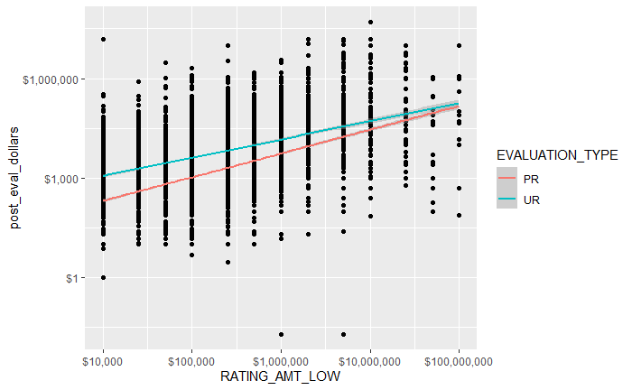

```r
merged_summary %>%
  filter(post_eval_dollars > 0) %>%
  ggplot(aes(x = RATING_AMT_LOW, y = post_eval_dollars)) +
  geom_point() +
  geom_smooth(method = "lm", aes(color = EVALUATION_TYPE)) +
  #geom_smooth(method = "loess", color = "red") +
  scale_y_log10(labels = dollar_format()) +
  scale_x_log10(labels = dollar_format())
```

Confirmed; PR line has a steeper slope.

Probability model: does eval type or other variables influence likelihood to give?

```r
glm1 <- merged_summary %>%
  glm(
    gave ~ eval_fy + log10(RATING_AMT_LOW) * EVALUATION_TYPE
    , family = "binomial"
    , data = .
  )

glm1 %>% summary()
```

```
Call:
glm(formula = gave ~ eval_fy + log10(RATING_AMT_LOW) * EVALUATION_TYPE,
    family = "binomial", data = .)

Deviance Residuals:
    Min       1Q   Median       3Q      Max
-1.6954  -1.2614   0.8468   1.0512   1.1847

Coefficients:
                                        Estimate Std. Error z value Pr(>|z|)
(Intercept)                             42.90817    3.78487  11.337  < 2e-16 ***
eval_fy                                 -0.02104    0.00187 -11.251  < 2e-16 ***
log10(RATING_AMT_LOW)                   -0.04276    0.02085  -2.051  0.04027 *
EVALUATION_TYPEUR                        1.11761    0.17599   6.350 2.15e-10 ***
log10(RATING_AMT_LOW):EVALUATION_TYPEUR -0.13156    0.03484  -3.776  0.00016 ***
---
Signif. codes:  0 ‘***’ 0.001 ‘**’ 0.01 ‘*’ 0.05 ‘.’ 0.1 ‘ ’ 1

(Dispersion parameter for binomial family taken to be 1)

    Null deviance: 43293  on 32283  degrees of freedom
Residual deviance: 42638  on 32279  degrees of freedom
  (2 observations deleted due to missingness)
AIC: 42648

Number of Fisher Scoring iterations: 4
```

Those who make it to a UR are more likely to give - again probably indicating MG activity. But interestingly, higher evaluated prospects are less likely to give, particularly if the eval type is UR.

## Final PR model

Look at PR rating and giving for everyone, including nondonors.

Probability model, including nondonors.

```r
glm_pr <- merged_summary %>%
  filter(EVALUATION_TYPE == "PR") %>%
  glm(
    gave ~ eval_fy + log10(RATING_AMT_LOW)
    , family = "binomial"
    , data = .
  )

summary(glm_pr)
```

```
Call:
glm(formula = gave ~ eval_fy + log10(RATING_AMT_LOW), family = "binomial",
    data = .)

Deviance Residuals:
    Min       1Q   Median       3Q      Max
-1.4765  -1.2514   0.9757   1.0945   1.1869

Coefficients:
                       Estimate Std. Error z value Pr(>|z|)
(Intercept)           43.871121   4.179902  10.496   <2e-16 ***
eval_fy               -0.021515   0.002065 -10.418   <2e-16 ***
log10(RATING_AMT_LOW) -0.043353   0.020880  -2.076   0.0379 *
---
Signif. codes:  0 ‘***’ 0.001 ‘**’ 0.01 ‘*’ 0.05 ‘.’ 0.1 ‘ ’ 1

(Dispersion parameter for binomial family taken to be 1)

    Null deviance: 29267  on 21362  degrees of freedom
Residual deviance: 29156  on 21360  degrees of freedom
  (2 observations deleted due to missingness)
AIC: 29162

Number of Fisher Scoring iterations: 4
```

```r
lm_pr <- merged_summary %>%
  filter(post_eval_dollars > 0 & EVALUATION_TYPE == "PR") %>%
  lm(
    log10(post_eval_dollars) ~ eval_fy + log10(RATING_AMT_LOW)
    , data = .
  )

summary(lm_pr)
```

```
Call:
lm(formula = log10(post_eval_dollars) ~ eval_fy + log10(RATING_AMT_LOW),
    data = .)

Residuals:
    Min      1Q  Median      3Q     Max
-5.4249 -0.5611 -0.0436  0.5079  3.6805

Coefficients:
                       Estimate Std. Error t value Pr(>|t|)
(Intercept)           13.300762   3.154602   4.216 2.52e-05 ***
eval_fy               -0.006879   0.001568  -4.388 1.16e-05 ***
log10(RATING_AMT_LOW)  0.716776   0.015367  46.644  < 2e-16 ***
---
Signif. codes:  0 ‘***’ 0.001 ‘**’ 0.01 ‘*’ 0.05 ‘.’ 0.1 ‘ ’ 1

Residual standard error: 0.821 on 6450 degrees of freedom
Multiple R-squared:  0.2525,    Adjusted R-squared:  0.2523
F-statistic:  1089 on 2 and 6450 DF,  p-value: < 2.2e-16
```

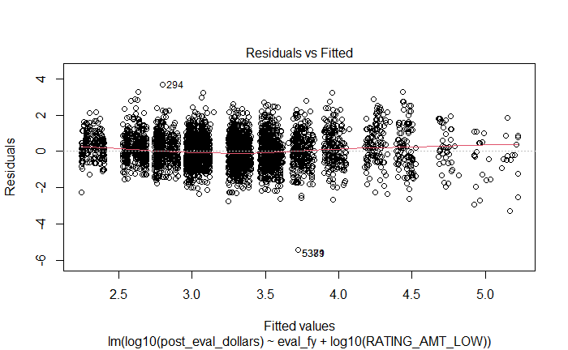

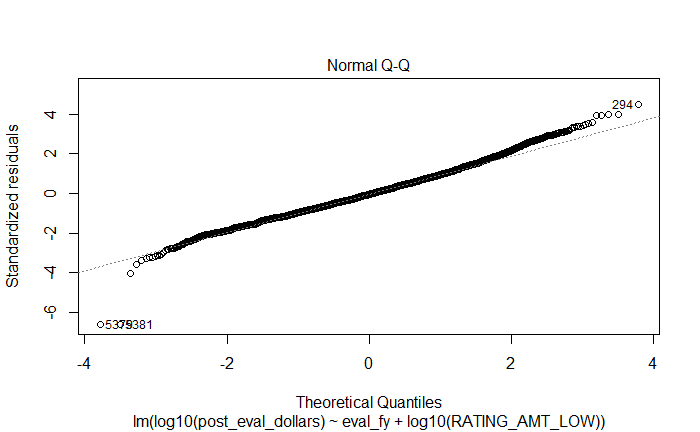

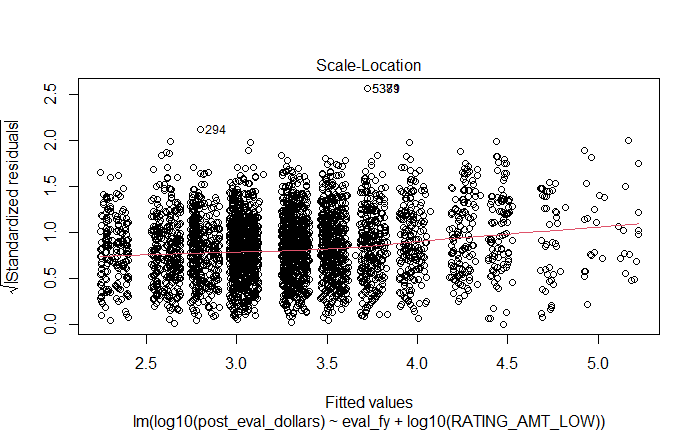

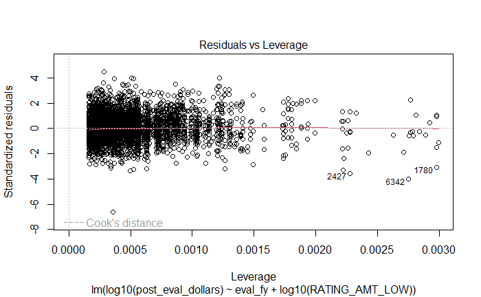

```r
plot(lm_pr)
```

# Conclusions

Looking at the final models of prospect research rated entities:

- Higher ratings may be associated with a marginally *lower* likelihood to give (negative sign on log10 rating amount)
- Conditional on making a gift, higher ratings are associated with higher giving. On the log scale, 1 unit increase in rating ~= 0.7 increase in giving.

Converted back to the unit scale:

$10^{0.7} =$ 5.01

So conditional on making a gift, a 10x higher research rating is associated with about a 5x larger gift.

On the other hand, for UOR ratings:

- Conditional on making a gift, a log 1 unit increase in rating ~= 0.52 log increase in giving

$10^{0.52} =$ 3.31

A 10x higher UOR is only associated with a 3.3x larger gift.

Looks like UORs may be associated with some degree of underasking and/or optimism.